# Презентация по лабораторной работе №3

Агентное моделирование

Люпп Софья Романовна

1132236039@rudn.ru

Российский университет дружбы народов

2026-03-16

# Информация

## Докладчик

- Люпп Софья Романовна
- студентка группы НКНбд-01-23
- кафедра теории вероятностей и кибербезопасности
- Российский университет дружбы народов им. П. Лумумбы
- [1132236039@rudn.ru]
- https://github.com/srluipp

# Вводная часть

## Актуальность

Агентное моделирование используется в экологии, экономике (рынки, поведение потребителей), социологии (распространение мнений, сегрегация), эпидемиологии (распространение инфекций), транспорте (движение пешеходов и автомобилей), политологии и многих других областях.

## Объект и предмет исследования

Обьектами исследования являются агентный подход к моделированию и модель daisyworld.

## Цели

- Ознакомиться с принципами агентного моделирования;
- Изучить модель daisyworld;
- Построить графики daisyworld в соответствии с принципами агентного моделирования.

## Задачи

— Установить необходимые пакеты; — Выполнить предложенный код; — Преобразовать код в литературный стиль; — Выполнить документацию в формате Quarto; — Выполнить код из jupyter notebook; — Интегрировать документацию в формате Quarto в отчёт; — Добавить в код в литературном стиле; — Результирующие файлы выложить на git.

## Материалы и методы

- Имитационное моделирование. Практикум. А. В. Королькова, Кулябов Д. С.

# Выполнение лабораторной работы №3

## Простая визуализация температуры поверхности модели

Создаю файлы src/daisyworld.jl, где определяется тип агента и функции шага модели, а затем файл scripts/daisyworld.jl - тепловую карту, которая представляет собой температуру поверхности модели (рис. 1).

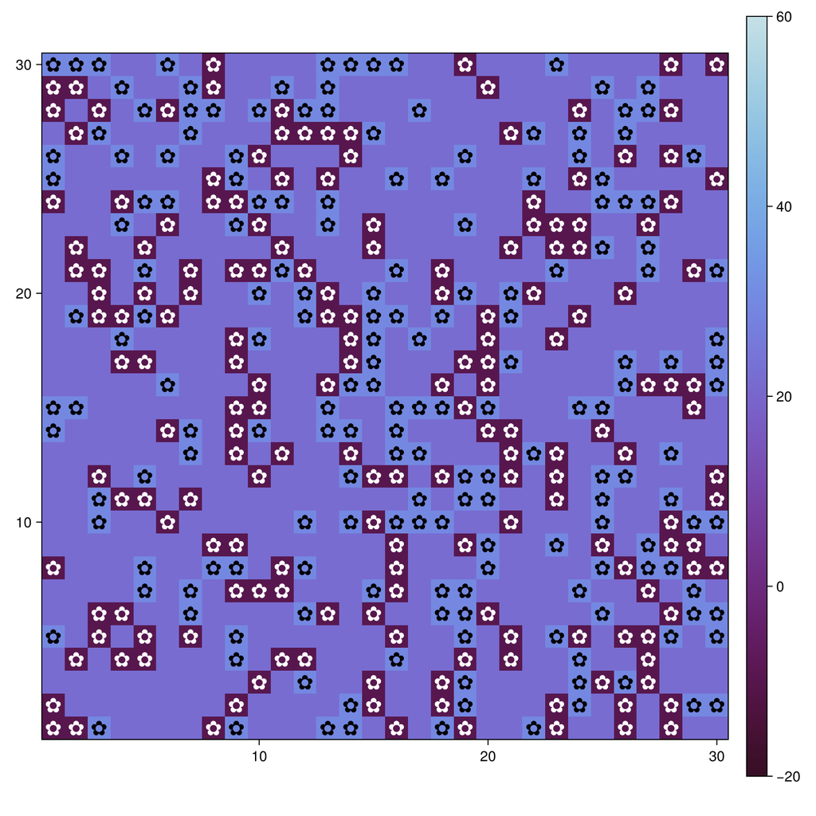

Рисунок 1: Тепловая карта daisyworld

## Тепловая карта модели маргариток

(рис. 2).

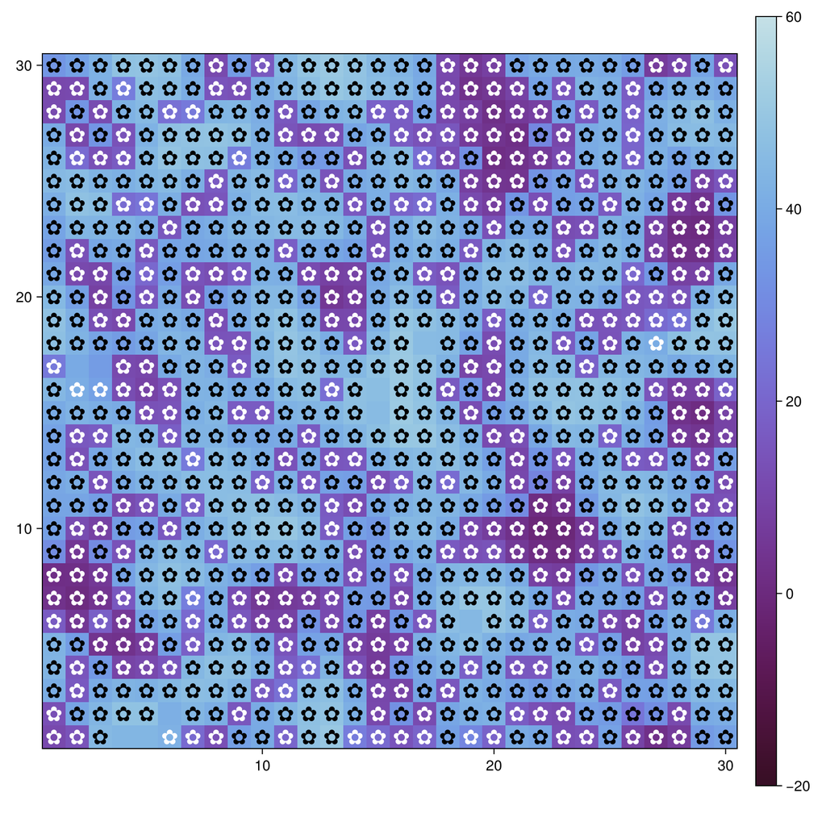

Рисунок 2: Тепловая карта daisyworld

## Тепловая карта модели маргариток

(рис. 3).

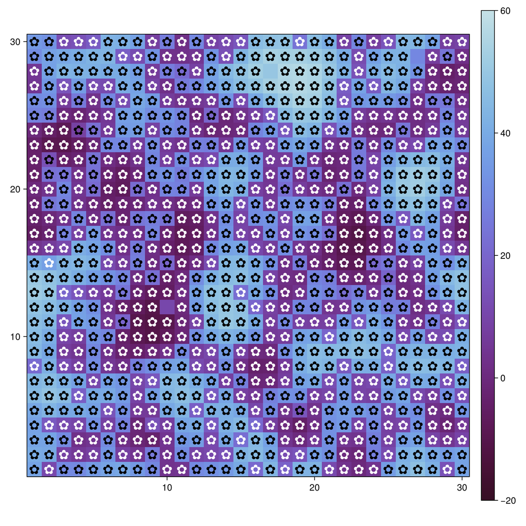

Рисунок 3: Тепловая карта daisyworld

## Анимация

Также была выполнена простая анимация эволюции модели с маргаритками (рис. 4).

[figure not shown]

Рисунок 4: Анимация

## Динамика числа маргариток

Построим график изменения числа маргариток в зависимости от модельного времени daisyworld-count.jl (рис. 5).

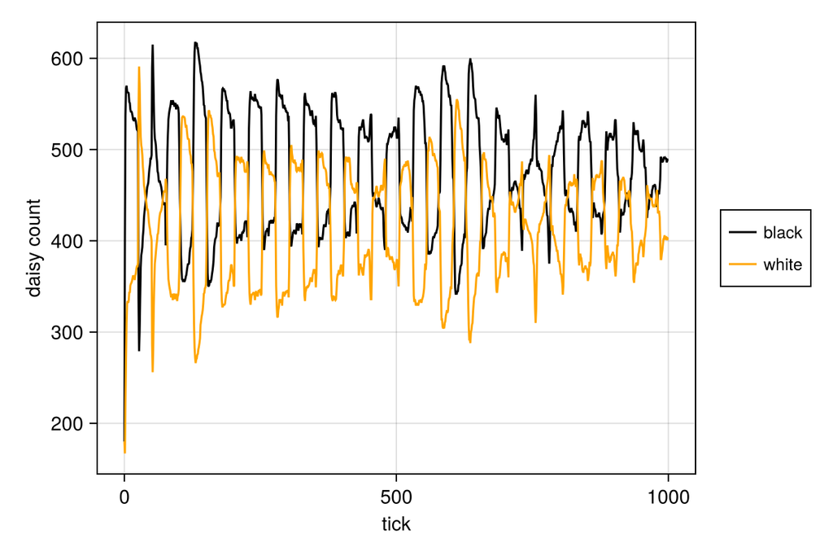

Рисунок 5: Динамика числа маргариток

## Динамика модели

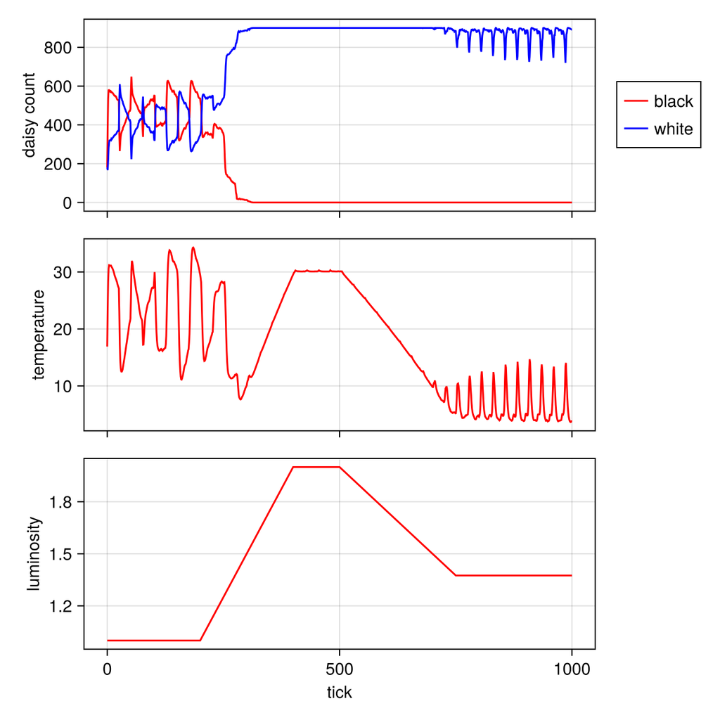

Рисунок 6: Динамика модели

## Базовая визуализация (параметры)

Расширим базовую визуализацию за счёт параметров - создадим файл daisyworld__param.jl и исследуем зависимость от параметров на нескольких примерах(рис. 7).

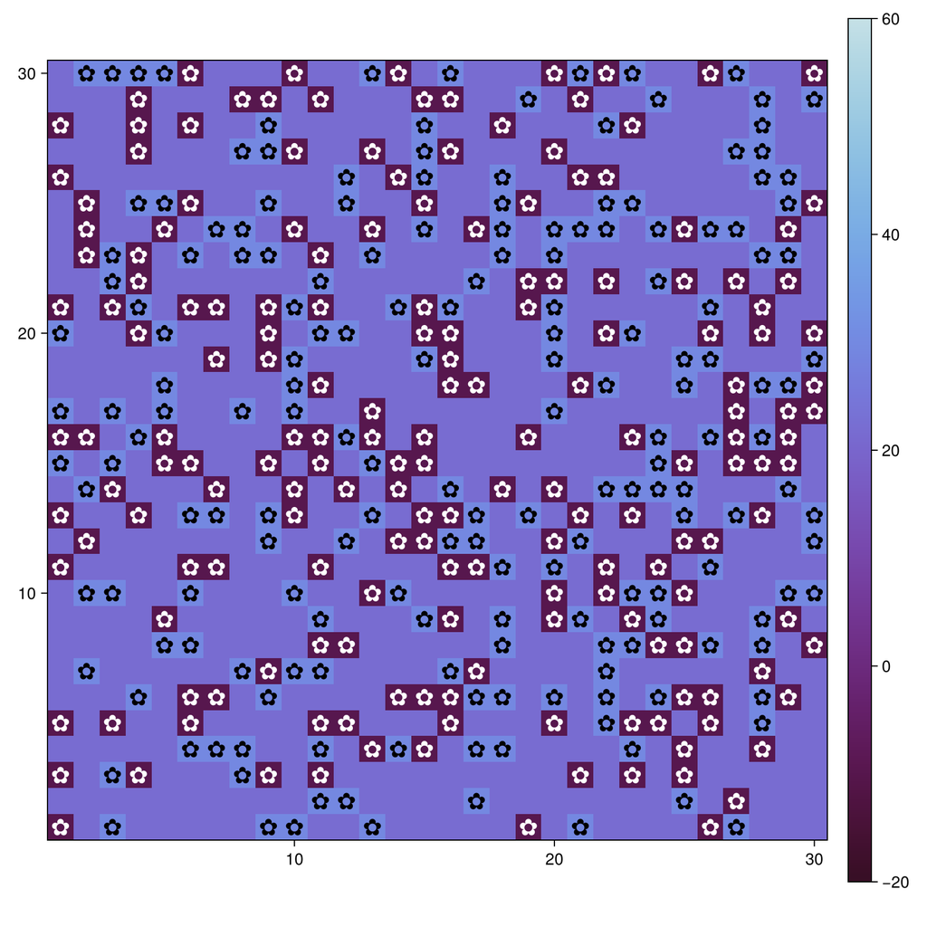

Рисунок 7: Визуализация модели в зависимости от параметров

## Базовая визуализация (параметры)

(рис. 8).

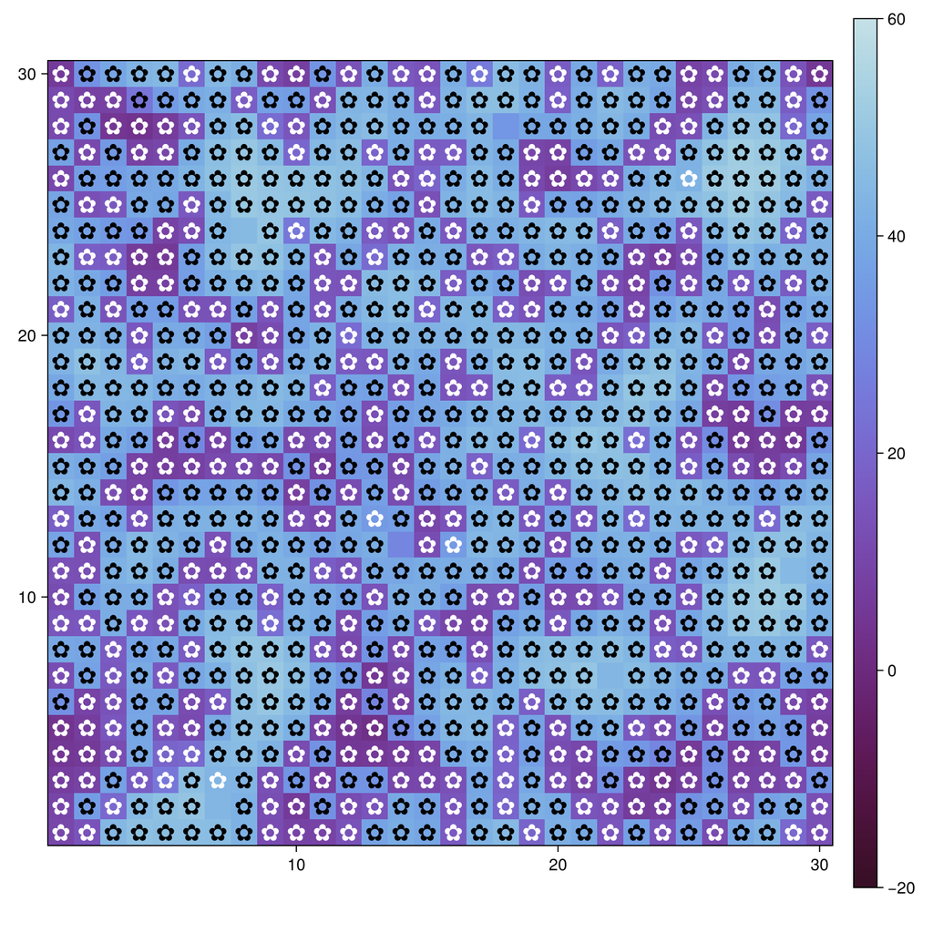

Рисунок 8: Визуализация модели в зависимости от параметров

## Базовая визуализация (параметры)

(рис. 9).

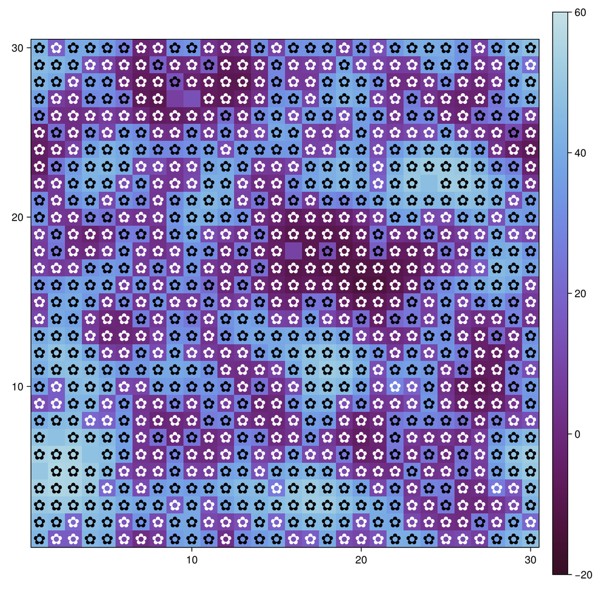

Рисунок 9: daisyworld__param.jl

## Динамика числа маргариток (параметры)

Построим график изменения числа маргариток в зависимости от модельного времени с разными параметрами модели в daisyworld-count__param.jl (рис. 10).

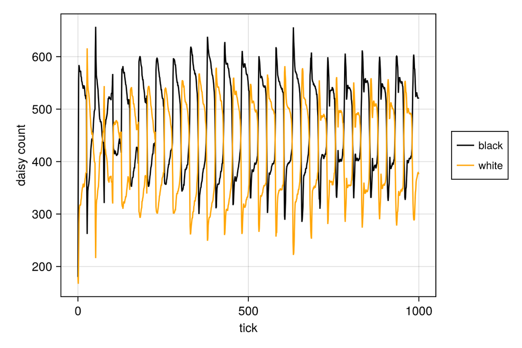

Рисунок 10: Динамика числа маргариток от параметров

## Динамика числа маргариток (параметры)

(рис. 11).

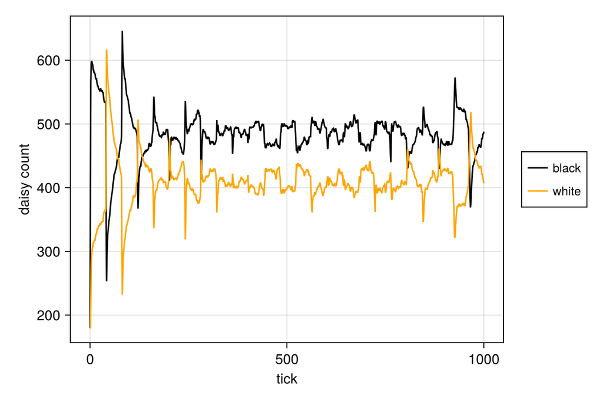

Рисунок 11: Динамика числа маргариток от параметров

## Динамика числа маргариток (параметры)

(рис. 12).

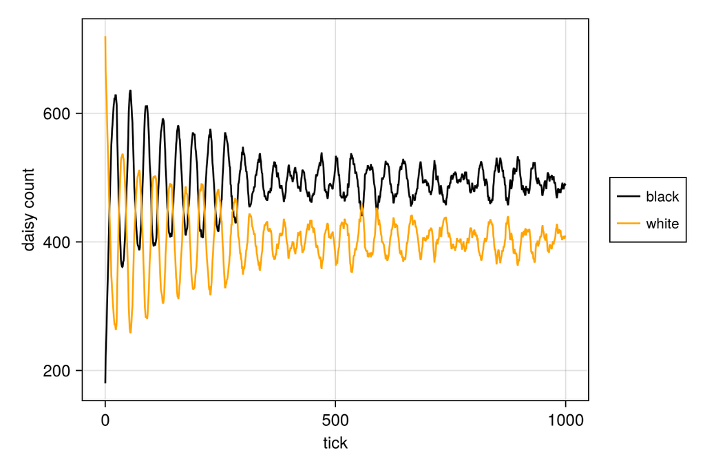

Рисунок 12: Динамика числа маргариток от параметров

## Динамика модели (параметры)

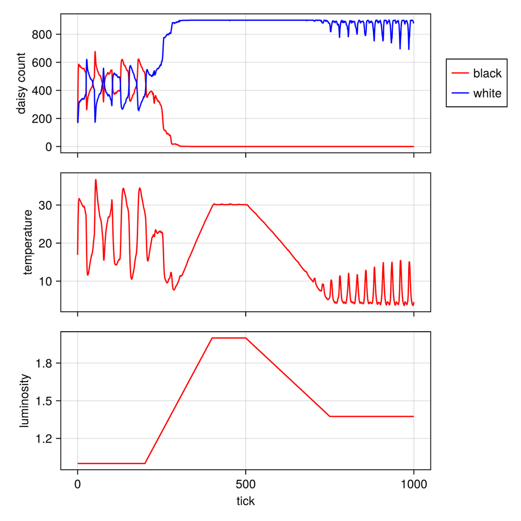

Рисунок 13: Динамика модели от параметров

## Динамика модели (параметры)

(рис. 14)

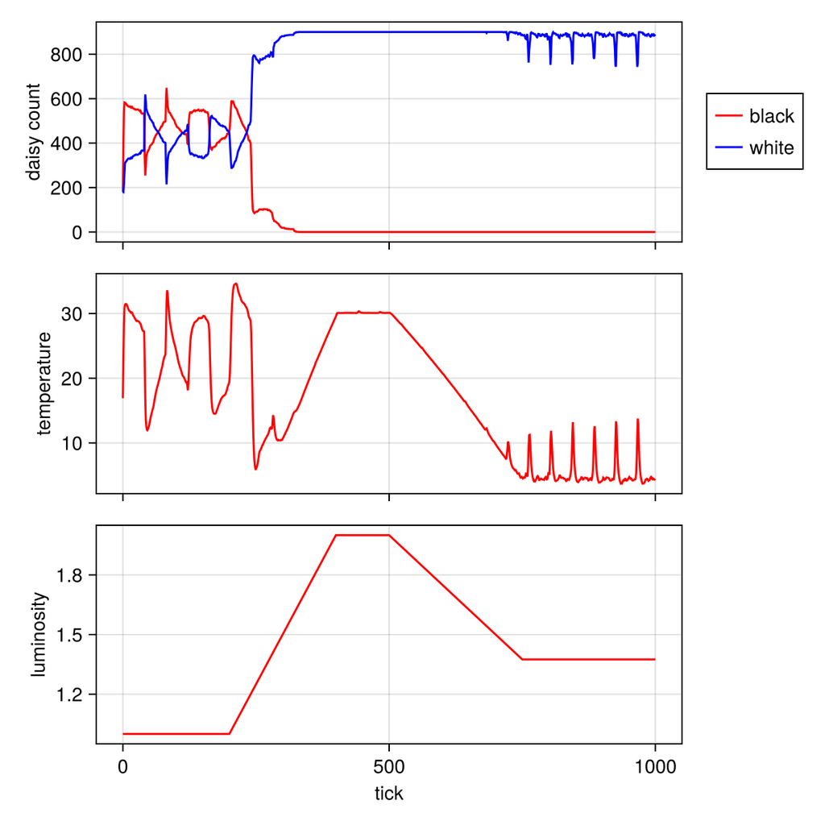

Рисунок 14: Динамика модели от параметров

## Динамика модели (параметры)

(рис. 15)

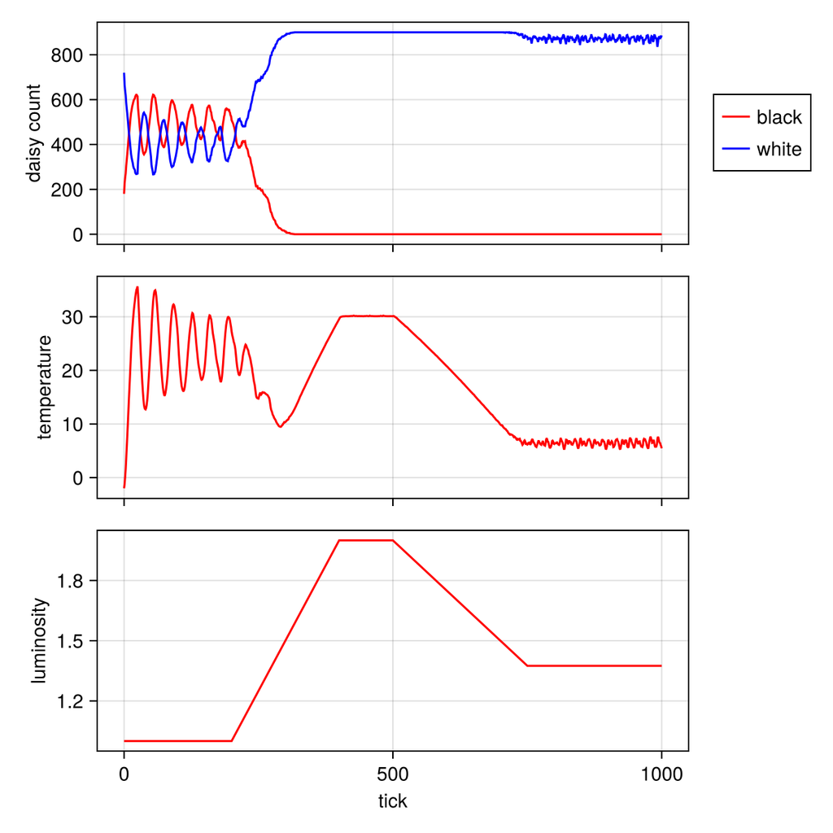

Рисунок 15: Динамика модели от параметров

## Динамика модели (параметры)

(рис. 16)

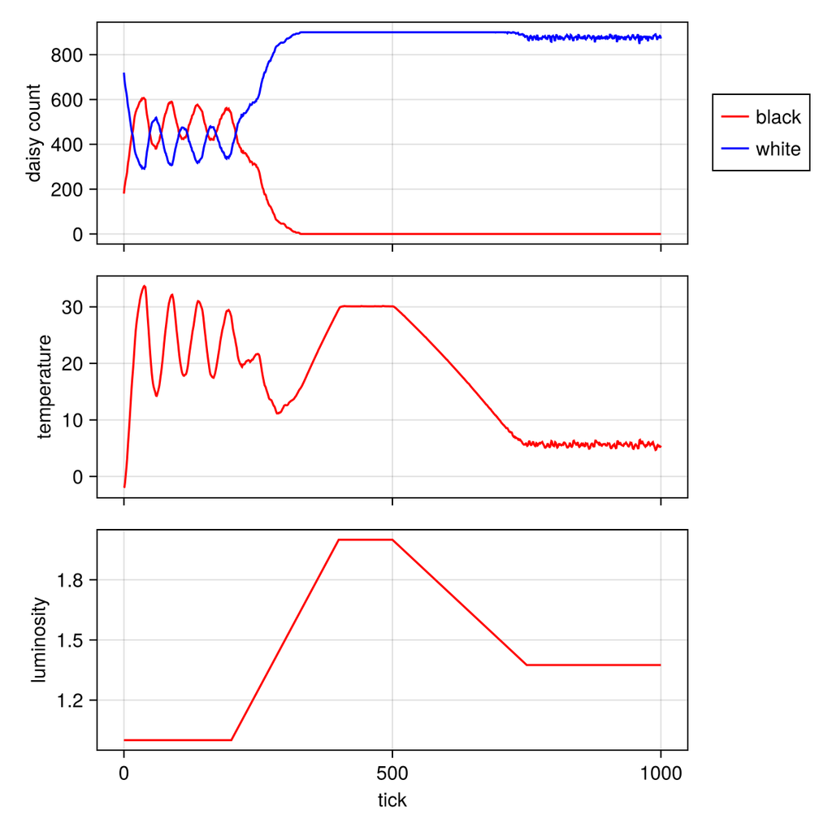

Рисунок 16: Динамика модели от параметров

# Результаты

Результатами данной лабораторной работы являются получившиеся графики модели daisyworld, произведенные при помощи окружении Julia и пакетом Agents для агентного моделирования.

## Итоговый слайд

(рис. 17)

[figure not shown]

Рисунок 17: Агентное моделирование